# Prediction Assignment

Nikhil

October 27, 2016

## 1. Synopsis

Using devices such as Jawbone Up, Nike FuelBand, and Fitbit it is now possible to collect a large amount of data about personal activity relatively inexpensively. These type of devices are part of the quantified self movement - a group of enthusiasts who take measurements about themselves regularly to improve their health, to find patterns in their behavior, or because they are tech geeks.

One thing that people regularly do is quantify how much of a particular activity they do, but they rarely quantify how well they do it. In this project, we will use data recorded from accelerometers on the belt, forearm, arm, and dumbbell of 6 participants. They were asked to perform barbell lifts correctly and incorrectly in 5 different ways.

More information is available from the website [http://groupware.les.inf.puc-rio.br/har[http://groupware.les.inf.puc-rio.br/har]](http://groupware.les.inf.puc-rio.br/har%5Bhttp://groupware.les.inf.puc-rio.br/har%5D) (see the section on the Weight Lifting Exercise Dataset).

The goal of this project is to predict the manner in which the participants did the exercise. This is the classe variable of the training set, which classifies the correct and incorrect outcomes into A, B, C, D, and E categories. This report describes how the model for the project was built, its cross validation, expected out of sample error calculation, and the choices made. It was used successfully to accurately predict all 20 different test cases on the Coursera website.

This document is the write-up submission for the course Practical Machine Learning that is part of Johns Hopkins Data Science Specialization. R version used for analysis is “R version 3.3.1 (2016-06-21)”. OS used is “x86_64, Windows 10 64 Bit”. R Studio version is 0.99.903

## 2. Basic settings

```r
knitr::opts_chunk$set(echo = TRUE)
echo = TRUE  # Make code always visible
options(scipen = 1)  # Turn off scientific notations for numbers
```

## 3. Loading the libraries

```r
library(RCurl)
library(caret)
library(rpart)
library(rpart.plot)
library(RColorBrewer)
library(rattle)
library(randomForest)
```

## 4. Reading the data and doing the preliminary validation

The training data for this project are available here: [https://d396qusza40orc.cloudfront.net/predmachlearn/pml-training.csv[https://d396qusza40orc.cloudfront.net/predmachlearn/pml-training.csv]](https://d396qusza40orc.cloudfront.net/predmachlearn/pml-training.csv%5Bhttps://d396qusza40orc.cloudfront.net/predmachlearn/pml-training.csv%5D)

The test data are available here: [https://d396qusza40orc.cloudfront.net/predmachlearn/pml-testing.csv[https://d396qusza40orc.cloudfront.net/predmachlearn/pml-testing.csv]](https://d396qusza40orc.cloudfront.net/predmachlearn/pml-testing.csv%5Bhttps://d396qusza40orc.cloudfront.net/predmachlearn/pml-testing.csv%5D)

Let’s download the data from the respective links and upload the files into R (using RStudio), interpreting the miscellaneous NA, #DIV/0! and empty fields as NA:

```r
#4.1 Read the data from the URLs given in Project Statement
trainingData = read.csv(textConnection(getURL("https://d396qusza40orc.cloudfront.net/predmachlearn/pml-training.csv")), na.strings = c("NA", "#DIV/0!", ""))
testingData  = read.csv(textConnection(getURL("https://d396qusza40orc.cloudfront.net/predmachlearn/pml-testing.csv")),  na.strings = c("NA", "#DIV/0!", ""))
```

Let’s have a quick look at the data in terms of structure, no. of observations, number and names of variables, etc.

```r
#4.2 Know more about structure and the data
str(trainingData)
```

```
## 'data.frame':    19622 obs. of  160 variables:
##  $ X                       : int  1 2 3 4 5 6 7 8 9 10 ...
##  $ user_name               : Factor w/ 6 levels "adelmo","carlitos",..: 2 2 2 2 2 2 2 2 2 2 ...
##  $ raw_timestamp_part_1    : int  1323084231 1323084231 1323084231 1323084232 1323084232 1323084232 1323084232 1323084232 1323084232 1323084232 ...
##  $ raw_timestamp_part_2    : int  788290 808298 820366 120339 196328 304277 368296 440390 484323 484434 ...
##  $ cvtd_timestamp          : Factor w/ 20 levels "02/12/2011 13:32",..: 9 9 9 9 9 9 9 9 9 9 ...
##  $ new_window              : Factor w/ 2 levels "no","yes": 1 1 1 1 1 1 1 1 1 1 ...
##  $ num_window              : int  11 11 11 12 12 12 12 12 12 12 ...
##  $ roll_belt               : num  1.41 1.41 1.42 1.48 1.48 1.45 1.42 1.42 1.43 1.45 ...
##  $ pitch_belt              : num  8.07 8.07 8.07 8.05 8.07 8.06 8.09 8.13 8.16 8.17 ...
##  $ yaw_belt                : num  -94.4 -94.4 -94.4 -94.4 -94.4 -94.4 -94.4 -94.4 -94.4 -94.4 ...
##  $ total_accel_belt        : int  3 3 3 3 3 3 3 3 3 3 ...
##  $ kurtosis_roll_belt      : num  NA NA NA NA NA NA NA NA NA NA ...
##  $ kurtosis_picth_belt     : num  NA NA NA NA NA NA NA NA NA NA ...
##  $ kurtosis_yaw_belt       : logi  NA NA NA NA NA NA ...
```

[output cut: 86 more lines]

```r
table(trainingData$classe)
```

```
##
##    A    B    C    D    E
## 5580 3797 3422 3216 3607
```

```r
prop.table(table(trainingData$user_name, trainingData$classe))
```

```
##
##                     A          B          C          D          E
##   adelmo   0.05937213 0.03954745 0.03822240 0.02624605 0.03496076
##   carlitos 0.04250331 0.03516461 0.02512486 0.02476812 0.03103659
##   charles  0.04581592 0.03796759 0.02746917 0.03271838 0.03623484
##   eurico   0.04408317 0.03017022 0.02492101 0.02966059 0.02762206
##   jeremy   0.05998369 0.02492101 0.03322801 0.02660279 0.02864132
##   pedro    0.03261645 0.02573642 0.02543064 0.02390174 0.02532871
```

```r
prop.table(table(trainingData$classe))
```

```
##
##         A         B         C         D         E
## 0.2843747 0.1935073 0.1743961 0.1638977 0.1838243
```

## 5. Cleaning the data

```r
#5.1 Let's start cleaning the data by removing all the unwanted columns
trainingData = trainingData[,7:160]
testingData = testingData[,7:160]

#5.2 Remove the NA columns
naData = apply (!is.na(trainingData), 2, sum) > 19621

trainingData = trainingData[,naData]
testingData = testingData[,naData]

#5.3 Verify the final structures for the training dataset
dim(trainingData)
```

```
## [1] 19622    54
```

```r
#5.4 Let's split the training set into two for cross validation purposes. We randomly subsample 60% of the set for training purposes (actual model building), while the 40% remainder will be used only for testing, evaluation and accuracy measurement.
splitUpRows = createDataPartition(y=trainingData$classe,p=0.6, list=FALSE)
finalTraining = trainingData[splitUpRows,]
finalTesting = trainingData[-splitUpRows,]
dim(finalTraining)
```

```
## [1] 11776    54
```

```r
dim(finalTesting)
```

```
## [1] 7846   54
```

```r
#5.5 Let's remove the Near Zero Variance columns from both the datasets
NearZeroVariance_columns=nearZeroVar(finalTraining)
if (length(NearZeroVariance_columns)>0)
{
  finalTraining = finalTraining[,-NearZeroVariance_columns]
  finalTesting = finalTesting[, -NearZeroVariance_columns]
}

#5.6 Verify the final structures for both the datasets
str (finalTraining)
```

```
## 'data.frame':    11776 obs. of  54 variables:
##  $ num_window          : int  11 11 11 12 12 12 12 12 12 12 ...
##  $ roll_belt           : num  1.41 1.41 1.42 1.48 1.45 1.42 1.45 1.42 1.42 1.45 ...
##  $ pitch_belt          : num  8.07 8.07 8.07 8.05 8.06 8.09 8.18 8.2 8.21 8.2 ...
##  $ yaw_belt            : num  -94.4 -94.4 -94.4 -94.4 -94.4 -94.4 -94.4 -94.4 -94.4 -94.4 ...
##  $ total_accel_belt    : int  3 3 3 3 3 3 3 3 3 3 ...
##  $ gyros_belt_x        : num  0 0.02 0 0.02 0.02 0.02 0.03 0.02 0.02 0 ...
##  $ gyros_belt_y        : num  0 0 0 0 0 0 0 0 0 0 ...
##  $ gyros_belt_z        : num  -0.02 -0.02 -0.02 -0.03 -0.02 -0.02 -0.02 0 -0.02 0 ...
##  $ accel_belt_x        : int  -21 -22 -20 -22 -21 -22 -21 -22 -22 -21 ...
##  $ accel_belt_y        : int  4 4 5 3 4 3 2 4 4 2 ...
##  $ accel_belt_z        : int  22 22 23 21 21 21 23 21 21 22 ...
##  $ magnet_belt_x       : int  -3 -7 -2 -6 0 -4 -5 -3 -8 -1 ...
##  $ magnet_belt_y       : int  599 608 600 604 603 599 596 606 598 597 ...
##  $ magnet_belt_z       : int  -313 -311 -305 -310 -312 -311 -317 -309 -310 -310 ...
```

[output cut: 40 more lines]

```r
str (finalTesting)
```

```
## 'data.frame':    7846 obs. of  54 variables:
##  $ num_window          : int  12 12 12 12 12 12 12 13 13 13 ...
##  $ roll_belt           : num  1.48 1.42 1.43 1.45 1.43 1.59 1.6 1.53 1.55 1.54 ...
##  $ pitch_belt          : num  8.07 8.13 8.16 8.17 8.18 8.07 8.1 8.11 8.09 8.11 ...
##  $ yaw_belt            : num  -94.4 -94.4 -94.4 -94.4 -94.4 -94.4 -94.4 -94.4 -94.4 -94.4 ...
##  $ total_accel_belt    : int  3 3 3 3 3 3 3 3 3 3 ...
##  $ gyros_belt_x        : num  0.02 0.02 0.02 0.03 0.02 0.02 0.02 0.03 0.02 0.03 ...
##  $ gyros_belt_y        : num  0.02 0 0 0 0 0 0 0 0 0 ...
##  $ gyros_belt_z        : num  -0.02 -0.02 -0.02 0 -0.02 -0.02 -0.02 0 0 -0.02 ...
##  $ accel_belt_x        : int  -21 -22 -20 -21 -22 -22 -20 -19 -21 -22 ...
##  $ accel_belt_y        : int  2 4 2 4 2 5 1 4 3 3 ...
##  $ accel_belt_z        : int  24 21 24 22 23 22 20 21 22 22 ...
##  $ magnet_belt_x       : int  -6 -2 1 -3 -2 -1 -10 -8 -10 3 ...
##  $ magnet_belt_y       : int  600 603 602 609 602 604 607 605 601 597 ...
##  $ magnet_belt_z       : int  -302 -313 -312 -308 -319 -314 -304 -319 -312 -320 ...
```

[output cut: 40 more lines]

## 6. Manipulating the data

We still have a lot of variables (53). Hence we try to look at their relative importance using the output of a quick Random Forest algorithm (which we call directly using randomForest()), and plotting data importance using varImpPlot():

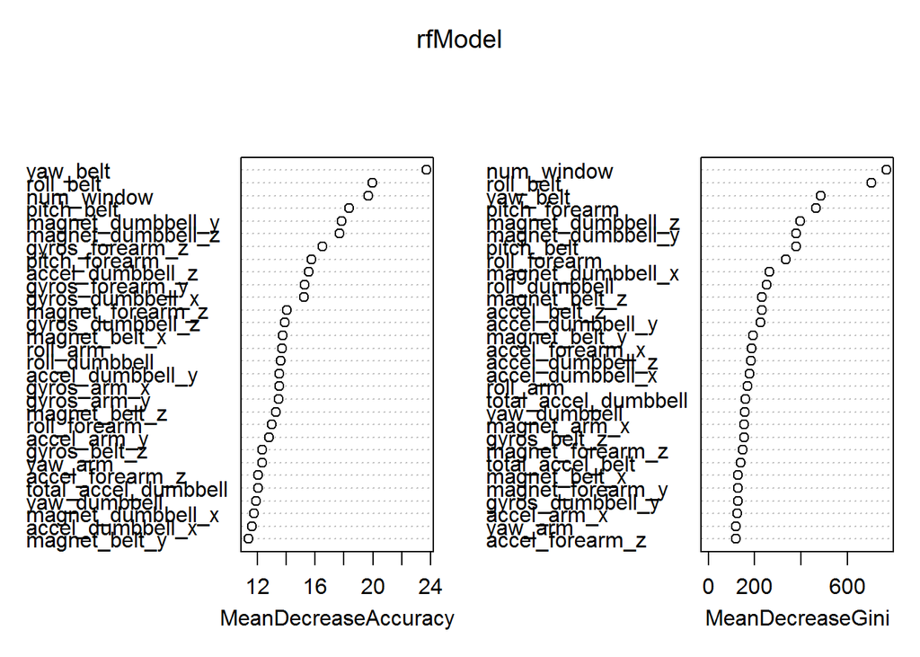

```r
#6.1 Create random forest model
rfModel = randomForest(classe~.,data=finalTraining,importance=TRUE, ntree=100)
varImpPlot(rfModel)
```

Using the varImpPlot output (Accuracy and Gini graphs above), we select the top 10 variables to use for model building. If the accuracy of the resulting model is acceptable, limiting the number of variables is a good idea to ensure readability and interpretability of the model. A model with 10 parameters is certainly user friendly and with less overheads than a model with 53 parameters.

Let’s analyze the correlations between these 10 variables. The code below calculates the correlation matrix, replaces the 1s in the diagonal with 0s, and outputs which variables have an absolute value correlation above 75%:

```r
#6.2 Verify the corelation among the selected 10 variables
corr = cor(finalTraining[,c("yaw_belt", "roll_belt", "num_window", "pitch_belt", "magnet_dumbbell_z", "magnet_dumbbell_y", "pitch_forearm", "accel_dumbbell_y", "roll_arm", "roll_forearm")])
diag(corr) = 0
which(abs(corr)>0.75,arr.ind = TRUE)
```

```
##           row col
## roll_belt   2   1
## yaw_belt    1   2
```

The two varaibles `roll_belt` and `yaw_belt` are having a very high correlation (> 75%) with each other. We may encounter challenges during modelling and predictions stage.

```r
#6.3 Verify and plot the correlation and relationship between roll_belt and yaw_belt variables
cor(finalTraining$roll_belt, finalTraining$yaw_belt)
```

```
## [1] 0.8156125
```

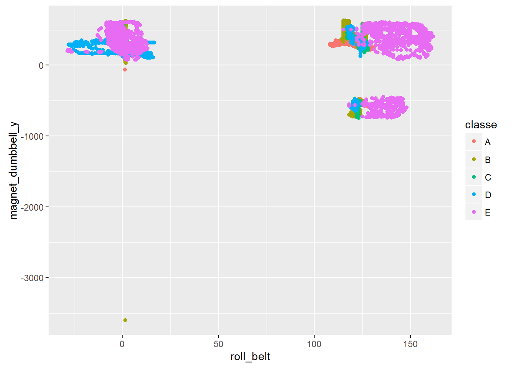

```r
qplot (roll_belt, magnet_dumbbell_y,colour=classe, data=finalTraining)
```

The graph above helps us to identify relationship between `roll_belt` and `magnet_dumbbell_y` variables. It suggests that we can probably bucket the data into groups based on `roll_belt` values. Subsequently, a quick tree classifier (shown below) selects `roll_belt` as the first discriminant among all 53 covariates.

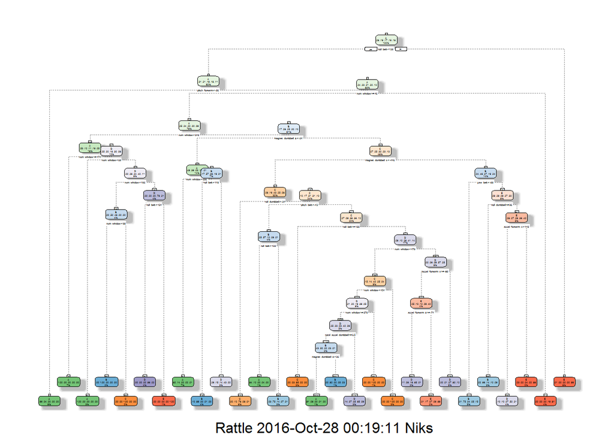

```r
#6.4 Plot the Decision Tree
fitModel = rpart(classe~., data=finalTraining, method="class")
fancyRpartPlot(fitModel)
```

Let’s not investigate tree classifiers further as the Random Forest algorithm is proving satisfactory.

## 7. Modelling and Prediction

We will use a 2-fold cross-validation control. This is the simplest k-fold cross-validation possible. Because the data set is large, using a small number of folds is justified.

```r
#7.1 Create the final model
finalModel = train(classe~roll_belt+num_window+pitch_belt+magnet_dumbbell_y+magnet_dumbbell_z+pitch_forearm+accel_dumbbell_y+roll_arm+roll_forearm,
                   data=finalTraining,
                   method="rf",
                   trControl=trainControl(method="cv",number=2),
                   prox=TRUE,
                   verbose=TRUE,
                   allowParallel=TRUE)
```

Since the above modelling process is time consuming, we will save the already created model for future usage using `saveRDS` command. We can always use this model again directly by allocating it to a variable using the `readRDS` command.

```r
#7.2 Save and read it for future usage
saveRDS(finalModel, "finalModel.rds")
finalModel=readRDS("finalModel.rds")
```

#### Accuracy of the model

Let’s apply the model generated using training data to testing data and check the accuracy of the built model.We can achieve this by using `confusionMatrix()` function from `caret` package.

```r
#7.3 Compare the predictions and measure the accuracy
predictions=predict(finalModel, newdata=finalTesting)
cMatrix = confusionMatrix(predictions, finalTesting$classe)
cMatrix
```

```
## Confusion Matrix and Statistics
##
##           Reference
## Prediction    A    B    C    D    E
##          A 2232    1    0    0    0
##          B    0 1514    2    0    1
##          C    0    2 1366    9    0
##          D    0    1    0 1277   12
##          E    0    0    0    0 1429
##
## Overall Statistics
##
##                Accuracy : 0.9964
##                  95% CI : (0.9948, 0.9976)
##     No Information Rate : 0.2845
##     P-Value [Acc > NIR] : < 2.2e-16
##
##                   Kappa : 0.9955
##  Mcnemar's Test P-Value : NA
##
## Statistics by Class:
##
##                      Class: A Class: B Class: C Class: D Class: E
## Sensitivity            1.0000   0.9974   0.9985   0.9930   0.9910
## Specificity            0.9998   0.9995   0.9983   0.9980   1.0000
## Pos Pred Value         0.9996   0.9980   0.9920   0.9899   1.0000
## Neg Pred Value         1.0000   0.9994   0.9997   0.9986   0.9980
## Prevalence             0.2845   0.1935   0.1744   0.1639   0.1838
## Detection Rate         0.2845   0.1930   0.1741   0.1628   0.1821
## Detection Prevalence   0.2846   0.1933   0.1755   0.1644   0.1821
## Balanced Accuracy      0.9999   0.9984   0.9984   0.9955   0.9955
```

#### Estimation of the outliers error rate

```r
outliersClass = function(values, predicted)
{
  sum(predicted!=values)/length(values)
}

outliersErrRate = outliersClass(finalTesting$classe, predictions)
outliersErrRate
```

```
## [1] 0.003568697
```

## 8. Final Subision

Let’s predict the classification of the 20 observations of the testing data set mentioned in Project Statement.

```r
predictions = predict(finalModel, newdata=testingData)
testingData$classe = predictions
```

We create one .CSV file with all the results, presented in two columns (named problem_id and classe) and 20 rows of data:

```r
submit = data.frame(problem_id = testingData$problem_id, classe = predictions)
write.csv(submit, file = "predictions-assignment-submission.csv", row.names = FALSE)
```

We also create 20 .TXT files, to be uploded one by one in the website (the 20 files created are called problem_1.txt to problem_20.txt):

```r
finalAnswers = testingData$classe
writeSubmissionFile = function(x){
  n = length(x)
  for(i in 1:n){
    filename = paste0("problem_",i,".txt")
    write.table(x[i], file=filename, quote=FALSE, row.names=FALSE, col.names=FALSE)
  }
}
writeSubmissionFile(finalAnswers)
```

## 9. Conclusion

In this assignment, we accurately predicted the classification of 20 observations using a Random Forest algorithm trained on a subset of data using less than 20% of the covariates.

It may be interesting to apply the `rfModel` tree from the Random Forest algorithm obtained (without any re-calibration) to a completely new set of participants, to complement and validate the analysis (testing dataset).